# Columbus GDG

Slava Nikitin

July 19, 2017

## Problem Domain

Analyzing data and building intelligent systems

[Data science diagram](http://r4ds.had.co.nz/diagrams/data-science-explore.png)

## Modeling primitives (MADLIM)

1. Model
2. Algorithm
3. Data
4. Loss
5. Inference
6. Metric

[Design space diagram](https://qph.ec.quoracdn.net/main-qimg-d8998ad42e28eb27a4035ef3601c0f68)

## Software frameworks

1. Caffe
2. CNTK
3. MXNET
4. Tensorflow
5. Torch

## Tensorflow overview

1. Numerical + programming library
2. Parallelized/distributed
3. Several execution modes
4. Multi-platform
5. Several interface languages
6. Levels of APIs
7. Visualization
8. Model serving
9. Apache 2.0

[Architecture diagram](https://www.tensorflow.org/images/layers.png)

## Tensorflow programming

1. Tensors
2. Operators
3. Programming primitives
4. Data

[Data flow diagram](http://www.kdnuggets.com/wp-content/uploads/tensors_flowing.jpg)

## Neural nets for predictive modeling

[Neural network structure](https://www.analyticsvidhya.com/wp-content/uploads/2016/03/2.-ann-structure.jpg)

[Neural network as topological transformation](https://www.generativeart.com/on/cic/papersGA2003/b22_file/image004.gif)

```r
reticulate::use_virtualenv("~/Documents/quickInsights/tensorflow/")
require(tensorflow)
require(keras)
```

## Low-level tensoflow

Synthesize data

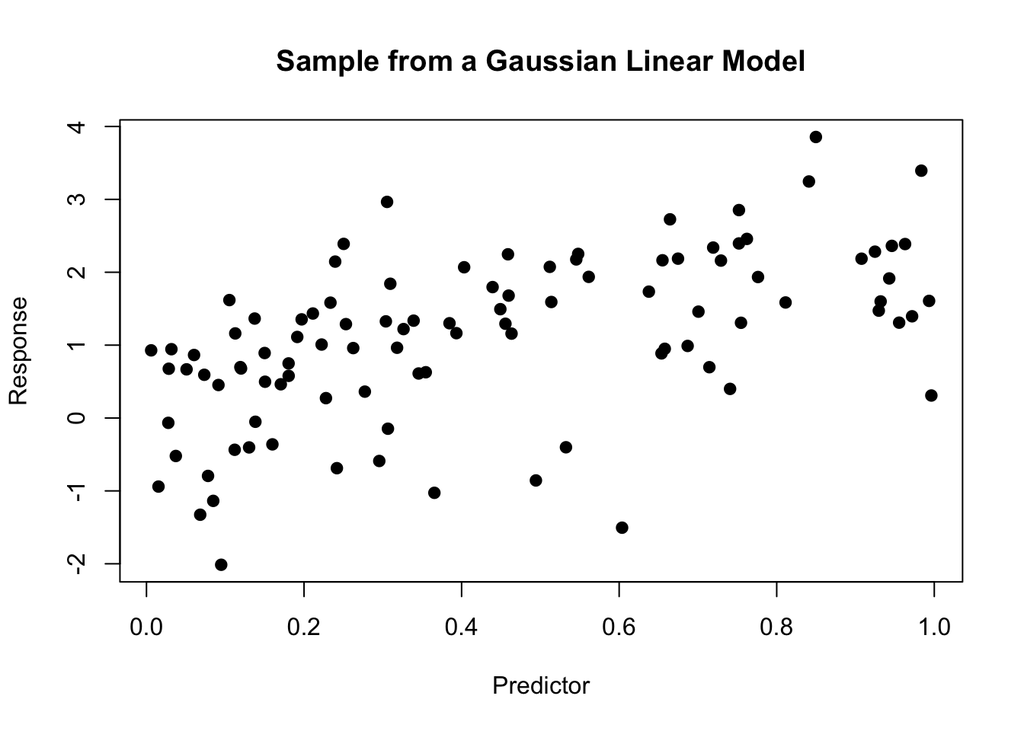

```r
set.seed(54934)
n = 100
intercept = .3
slope = 2
predictors_train = runif(n)
response_train = predictors_train * slope + intercept + rnorm(100)

predictors_test = runif(n)
response_test = predictors_test * slope + intercept + rnorm(100)

plot(
  predictors_train, response_train,
  xlab = "Predictor", ylab = "Response",
  main = "Sample from a Gaussian Linear Model",
  pch = 19
)
```

Prepare inputs/outputs and parameters by creating tensors.

```r
x = tf$placeholder(tf$float32, list(NULL, 1L))
y_obs = tf$placeholder(tf$float32, list(NULL, 1L))

W = tf$Variable(tf$random_uniform(shape(1L), -1.0, 1.0))
b = tf$Variable(tf$zeros(shape(1L)))
```

Define a flow of tensors through a sequence of operators that represent a linear systematic component

```r
y = tf$multiply(W, x) %>%
  tf$add(b)
```

then use a gaussian distribution to define the loss:

```r
loss = tf$subtract(y, y_obs) %>%
  tf$pow(2) %>%
  tf$reduce_mean()
```

Pick an algorithm, implicitly following maximum likelihood inference procedure:

```r
# stochastic optimizer
optimizer = tf$train$GradientDescentOptimizer(0.5)
train = optimizer$minimize(loss)
```

Set up the model and fit it to data

```r
# Launch the graph and initialize the variables.
sess = tf$Session()
sess$run(tf$global_variables_initializer())

# Fit the model
for (step in 1:200)
  sess$run(
    train,
    dict(x = as.matrix(predictors_train), y_obs = as.matrix(response_train))
  )

cat("Parameter estimates: ", "W = ", sess$run(W), ", ", "b = ", sess$run(b), sep = "")
```

```
## Parameter estimates: W = 2.056944, b = 0.2109323
```

```r
cat("Predictive accuracy:",
    sqrt(sess$run(loss, dict(x = as.matrix(predictors_test),
                             y_obs = as.matrix(response_test)))))
```

```
## Predictive accuracy: 1.108649
```

Some diagnostics for out of sample data:

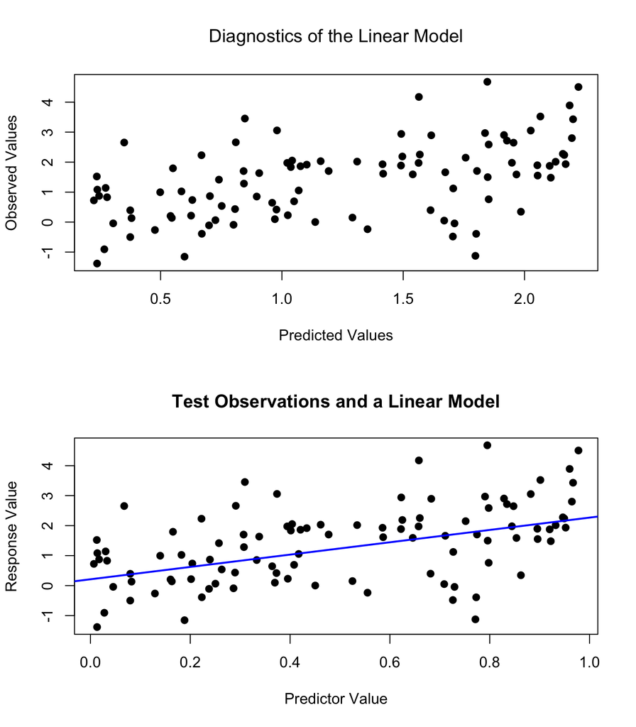

```r
y_pred = sess$run(y, dict(x = as.matrix(predictors_test)))
par(mfrow = c(2, 1))
plot(y_pred, response_test, xlab = "Predicted Values", ylab = "Observed Values",
     main = expression("Diagnostics of the Linear Model"), pch = 19)
plot(predictors_test, response_test, pch = 19, xlab = "Predictor Value",
     ylab = "Response Value", main = "Test Observations and a Linear Model")
abline(sess$run(b), sess$run(W), col = "blue", lwd = 2)
```

## Mid-level with Keras

### Continuous output

Get data:

```r
boston = dataset_boston_housing()
str(boston)
```

```
## List of 2
##  $ train:List of 2
##   ..$ x: num [1:404, 1:13] 1.2325 0.0218 4.8982 0.0396 3.6931 ...
##   ..$ y: num [1:404(1d)] 15.2 42.3 50 21.1 17.7 18.5 11.3 15.6 15.6 14.4 ...
##  $ test :List of 2
##   ..$ x: num [1:102, 1:13] 18.0846 0.1233 0.055 1.2735 0.0715 ...
##   ..$ y: num [1:102(1d)] 7.2 18.8 19 27 22.2 24.5 31.2 22.9 20.5 23.2 ...
```

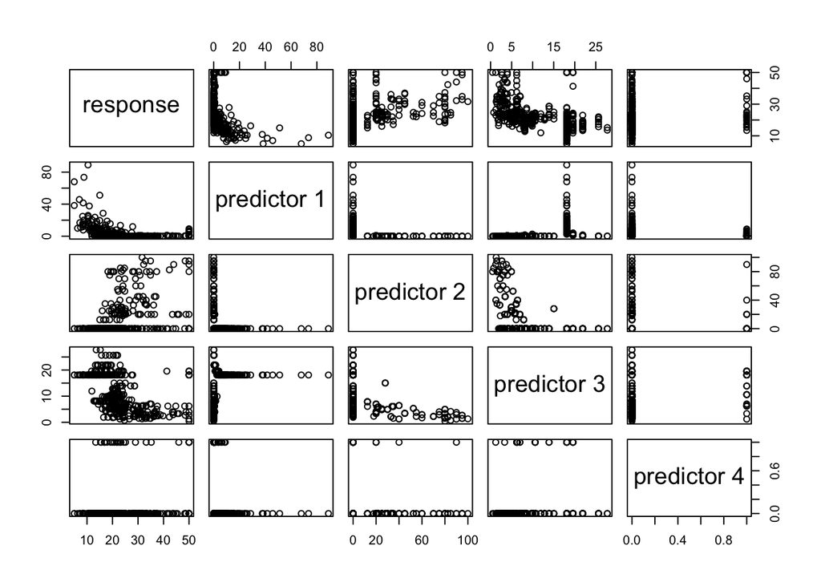

```r
predictors_train = boston$train$x
response_train = boston$train$y
predictors_test = boston$test$x
response_test = boston$test$y

plot_data = cbind(response_train, predictors_train)
colnames(plot_data) = c("response", paste(rep("predictor", 13), 1:13))
pairs(plot_data[, 1:5])
```

Define the systematic component:

```r
model = keras_model_sequential()

model %>%
  layer_dense(units = 13, activation = 'relu', input_shape = 13) %>%
  layer_dense(units = 1, activation = 'linear')

summary(model)
```

```
## Model
## ___________________________________________________________________________
## Layer (type)                     Output Shape                  Param #
## ===========================================================================
## dense_1 (Dense)                  (None, 13)                    182
## ___________________________________________________________________________
## dense_2 (Dense)                  (None, 1)                     14
## ===========================================================================
## Total params: 196.0
## Trainable params: 196
## Non-trainable params: 0.0
## ___________________________________________________________________________
##
##
```

Define the random component, inference algorithm, evaluation measure

```r
compile(
  model,
  loss = "mean_absolute_error",
  optimizer = "adam",
  metrics = "mean_absolute_error"
)
```

Estimate parameters

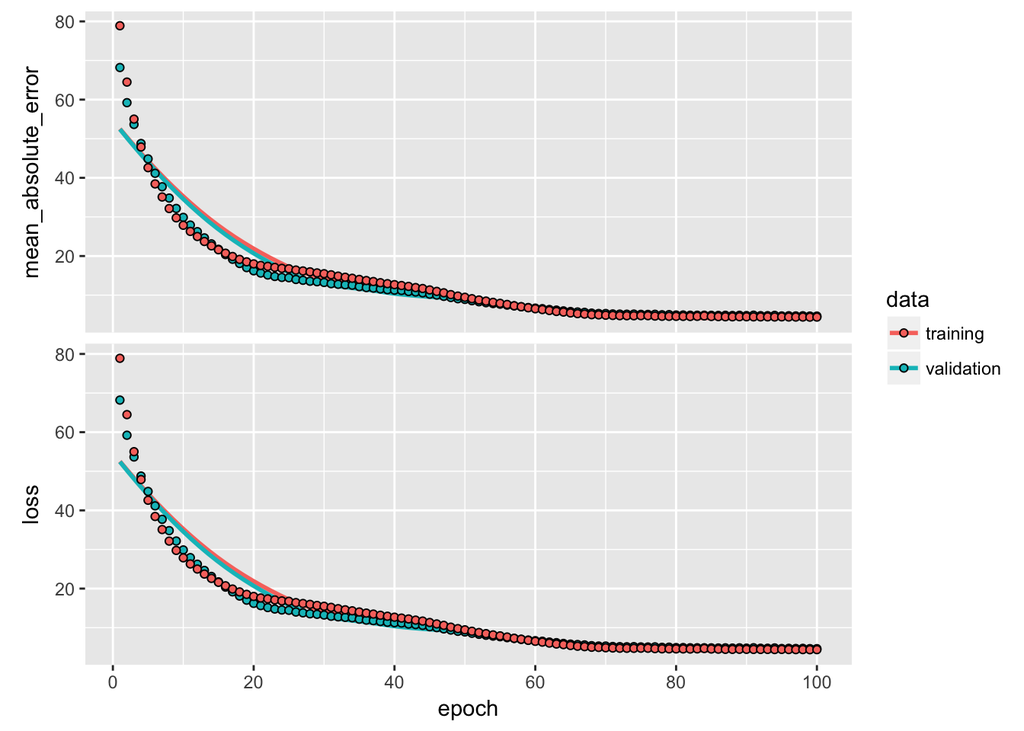

```r
history = fit(
  model,
  predictors_train, response_train,
  validation_data = list(predictors_test, response_test),
  batch_size = 64, epochs = 100
)

plot(history)
```

Prediction diagnostic

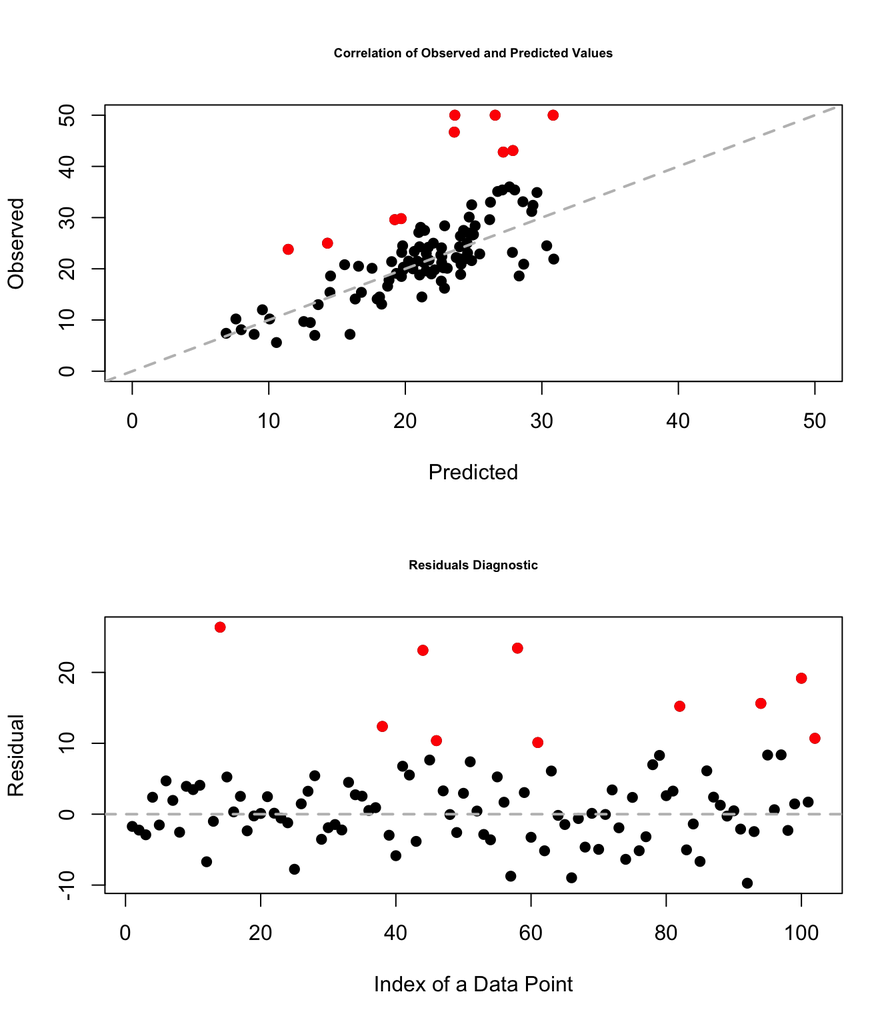

```r
# # Evaluate
# evaluate(model, predictors_test, response_test)

#
problems = as.double(predict(model, predictors_test)) - response_test > 10 |
  as.double(predict(model, predictors_test)) - response_test < -10

par(mfrow = c(2, 1))
plot(
  as.double(predict(model, predictors_test)), response_test,
  pch = 19, xlim = c(0, 50), ylim = c(0, 50),
  xlab = "Predicted", ylab = "Observed",
  main = "Correlation of Observed and Predicted Values",
  cex.main = .6
)
abline(a = 0, b = 1, lty = 2, lwd = 2, col = "grey")
points(as.double(predict(model, predictors_test))[problems],
       response_test[problems], col = "red", pch = 19)
plot(
  response_test - as.double(predict(model, predictors_test)),
  pch = 19,
  xlab = "Index of a Data Point", ylab = "Residual",
  main = "Residuals Diagnostic",
  cex.main = .6
)
abline(h = 0, lty = 2, lwd = 2, col = "grey")
points((1:length(response_test))[problems],
       (response_test - as.double(predict(model, predictors_test)))[problems],
       col = "red", pch = 19)
```

### Categorical output

Data prep

```r
max_words = 1000

cat('Loading data...\n')
```

```
## Loading data...
```

```r
reuters = dataset_reuters(num_words = max_words, test_split = 0.2)

predictors_train = reuters$train$x
response_train = reuters$train$y
predictors_test = reuters$test$x
response_test = reuters$test$y

cat(length(predictors_train), 'train sequences\n')
```

```
## 8982 train sequences
```

```r
cat(length(predictors_test), 'test sequences\n')
```

```
## 2246 test sequences
```

```r
num_classes = max(response_train) + 1
cat(num_classes, '\n')
```

```
## 46
```

```r
cat('Vectorizing sequence data...\n')
```

```
## Vectorizing sequence data...
```

```r
tokenizer = text_tokenizer(num_words = max_words)
predictors_train = sequences_to_matrix(tokenizer, predictors_train, mode = 'binary')
predictors_test = sequences_to_matrix(tokenizer, predictors_test, mode = 'binary')

cat('predictors_train shape:', dim(predictors_train), '\n')
```

```
## predictors_train shape: 8982 1000
```

```r
cat('predictors_test shape:', dim(predictors_test), '\n')
```

```
## predictors_test shape: 2246 1000
```

```r
cat('Convert class vector to binary class matrix',
    '(for use with categorical_crossentropy)\n')
```

```
## Convert class vector to binary class matrix (for use with categorical_crossentropy)
```

```r
response_train = to_categorical(response_train, num_classes)
response_test = to_categorical(response_test, num_classes)
cat('response_train shape:', dim(response_train), '\n')
```

```
## response_train shape: 8982 46
```

```r
cat('response_test shape:', dim(response_test), '\n')
```

```
## response_test shape: 2246 46
```

Define the systematic component

```r
cat('Building model...\n')
```

```
## Building model...
```

```r
model = keras_model_sequential()
model %>%
  layer_dense(units = 512, activation = "relu", input_shape = max_words) %>%
  layer_dropout(rate = 0.5) %>%
  layer_dense(units = num_classes, activation = "softmax")

summary(model)
```

```
## Model
## ___________________________________________________________________________
## Layer (type)                     Output Shape                  Param #
## ===========================================================================
## dense_3 (Dense)                  (None, 512)                   512512
## ___________________________________________________________________________
## dropout_1 (Dropout)              (None, 512)                   0
## ___________________________________________________________________________
## dense_4 (Dense)                  (None, 46)                    23598
## ===========================================================================
## Total params: 536,110.0
## Trainable params: 536,110.0
## Non-trainable params: 0.0
## ___________________________________________________________________________
##
##
```

Define the random component, inference algorithm, evaluation measure

```r
compile(
  model,
  loss = 'categorical_crossentropy',
  optimizer = 'adam',
  metrics = 'accuracy'
)
```

Fit model to data

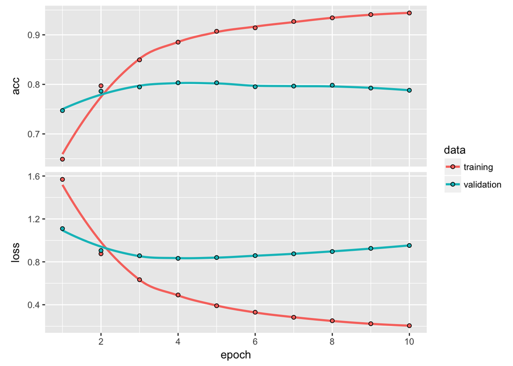

```r
batch_size = 64
epochs = 10

history = fit(
  model,
  predictors_train, response_train,
  batch_size = batch_size,
  epochs = epochs,
  verbose = 1,
  validation_data = list(predictors_test, response_test)
)

plot(history)
```

scalar metrics

```r
metrics = evaluate(
  model,
  predictors_test, response_test,
  batch_size = batch_size,
  verbose = 1
)

cat('Test loss:', metrics[[1]], '\n')
```

```
## Test loss: 0.9523294
```

```r
cat('Test accuracy', metrics[[2]], '\n')
```

```
## Test accuracy 0.7880677
```

Confusion matrix for more detail

```r
table("predicted" = predict_classes(model, predictors_test),
      "observed" = reuters$test$y)[1:9, 1:10]
```

```
##          observed
## predicted   0   1   2   3   4   5   6   7   8   9
##         0   7   0   0   0   1   0   0   0   0   0
##         1   2  82   1   2   5   4   0   1   0   1
##         2   0   1  13   0   0   0   0   0   0   0
##         3   0   6   0 765  27   0   0   1   3   0
##         4   1   5   0  33 418   0   1   0   3   3
##         5   0   0   0   0   0   1   0   0   0   0
##         6   0   0   0   0   1   0  13   0   0   0
##         7   0   0   0   0   0   0   0   1   0   0
##         8   0   1   0   2   1   0   0   0  28   0
```

## Additional resources

https://www.tensorflow.org/

[2017 TensorFlow Dev Summit videos](https://www.youtube.com/playlist?list=PLOU2XLYxmsIKGc_NBoIhTn2Qhraji53cv)

[2017 Google I/O videos](https://www.youtube.com/playlist?list=PLOU2XLYxmsIKC8eODk_RNCWv3fBcLvMMy)